# Chapter 5

## Chapter Outline

- Standardizing observations for comparisons
- The normal model
- 68-95-99.7 rule for the normal model
- Finding percentiles and areas for given observations from a normal model
- Finding observations for given percentiles or areas from a normal model

## Standardizing observations

## Comparing two variables

- ACT score
- SAT score
- Different scale
- Measuring similar values
- How do you compare them?

## Example 1

- The average score on the ACT English exam is 21.0, with a standard deviation of 4.0. The average score on the SAT verbal exam is 520 with a standard deviation of 100.
  - Albert scores a 27 on the ACT English exam
  - Alfred scores a 770 on the SAT Verbal exam
- Who has the better score? Albert or Alfred?

## Standardizing observations

- \(y =\) observation of quantitative variable
- How does the value of \(y\) relate to the mean value?
- How does the value of \(y\) for this quantitative variable relate to another observation of a different quantitative variable?

## Standardizing variables

\[z = \frac{y - \bar{y}}{s}\]

- \(z\) has no units (just a number)
- Puts observations on same scale
  - Mean (center) at 0
  - Standard deviation (spread) of 1
- Does not change overall shape of the distribution

## Standardizing variables

- \(z =\) # of standard deviations observation is away from mean
  - Negative \(z\): observation is below mean
    - Ex: \(z=-1.5\Rightarrow\) observation is 1.5 standard devations below mean
  - Positive \(z\): observation is above mean
    - Ex: \(z=0.5\Rightarrow\) observation is 0.5 standard deviations above mean

## Recall: Example 1

- The average score on the ACT English exam is 21.0, with a standard deviation of 4.0. The average score on the SAT verbal exam is 520 with a standard deviation of 100.
  - Albert scores a 27 on the ACT English exam
  - Alfred scores a 770 on the SAT Verbal exam
- How do we answer who has the better score?
  - Compute z-scores and compare

## Example 1

- Albert \[z = \frac{27-21}{4} = 1.5\]
- Alfred \[z = \frac{770 - 520}{100} = 2.5\]
- Who has the better scores?
  - Albert's score is 1.5 standard deviations above the mean, while Alfred's score is 2.5 standard deviations above the mean

## Example 2

- The average score on the ACT Math exam is 20.7 with a standard deviation of 4.1. The average score on the SAT Math exam is 510 with a standard deviation of 100
  - Alberta scores a 15 on the ACT Math exam
  - Fredda scores a 340 on the SAT Math exam
- Who has the better score? Alberta or Fredda?

## Example 2

- Alberta \[z = \frac{15-20.7}{4.1} = -1.39\]
- Fredda \[z = \frac{340 - 510}{100} = -1.70\]
- Who has the better score?
  - Alberta because she has a larger z-score
  - Alberta is only 1.39 standard deviations below the mean while Fredda is 1.70 standard deviations below the mean

## Distributions and standardizing

- Standardizing
  - Allows you to make comparisons of observations between different variables
  - Without the distribution information, you still don't know anything about the percentile value of your observation
  - This percentile value depends on the distribution

## Models for data distributions

- Different models according to different aspects of distributions
  - Shape
  - Center
  - Variability

## The Normal Model

## Normal Model

- Shape
  - Unimodal
  - Symmetric
  - Bell-shaped
- Determined by two parameters
  - Mean \((\mu)\)
  - Standard deviation \((\sigma)\)

## Connection to data

- No data distribution follows a normal model exactly
- Many data distributions are very close though
- How do you know?
  - Histogram
  - Normal Quantile Plot (will learn in lab)

## Example

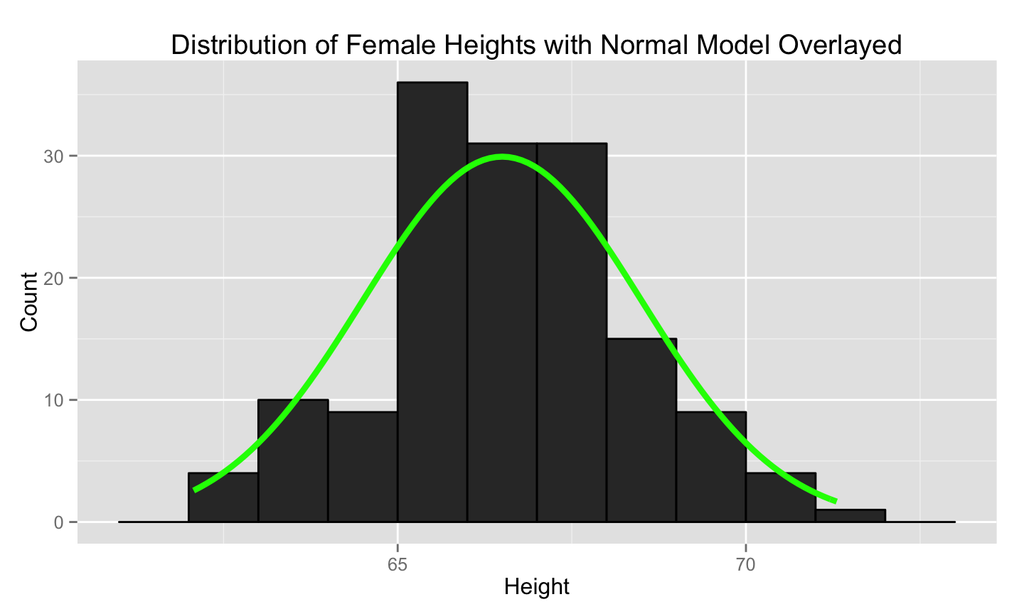

## A closer look at the normal model

- Mean \(\mu\)
  - Locates the center of the distribution
  - Splits the curve in half
- Standard deviation \(\sigma\)
  - Controls the variability of curve
  - Ruler of distribution
- Write as \(N(\mu, \sigma)\)

## Example

- Height of men is normally distributed
  - Mean \(\mu = 70\) inches
  - Standard deviation \(\sigma = 3\) inches
- So, the height of men is distributed \(N(70,3)\)
- What percent of men have heights less than 70 inches?
  - 50%
- What percent of men have heights greater than 70 inches?
  - 50%

## Example - Height of men

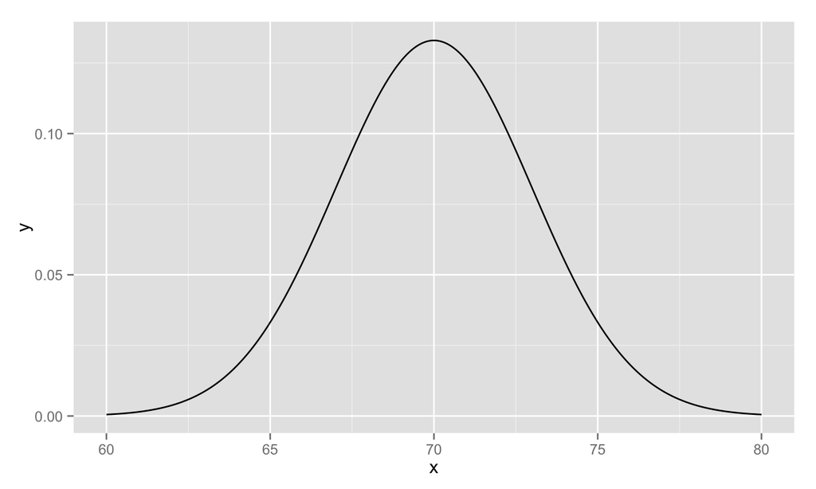

## 68-95-99.7 rule

## 68-95-99.7 rule

- Approximately 68% of observations are within 1 \(\sigma\) of the mean \(\mu\)
- If \(\mu = 0\) and \(\sigma = 1\), approximately 68% of the observations are between -1 and 1

## 68-95-99.7 rule

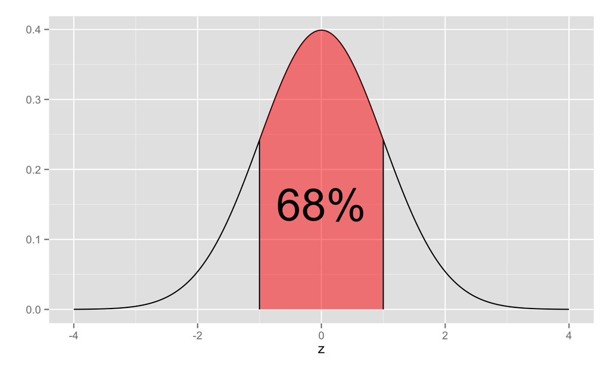

## 68-95-99.7 rule

- Approximately 95% of observations are within \(2\sigma\) of the mean \(\mu\)
- If \(\mu = 0\) and \(\sigma = 1\), approximately 95% of the observations are between \(-2\) and \(2\)

## 68-95-99.7 rule

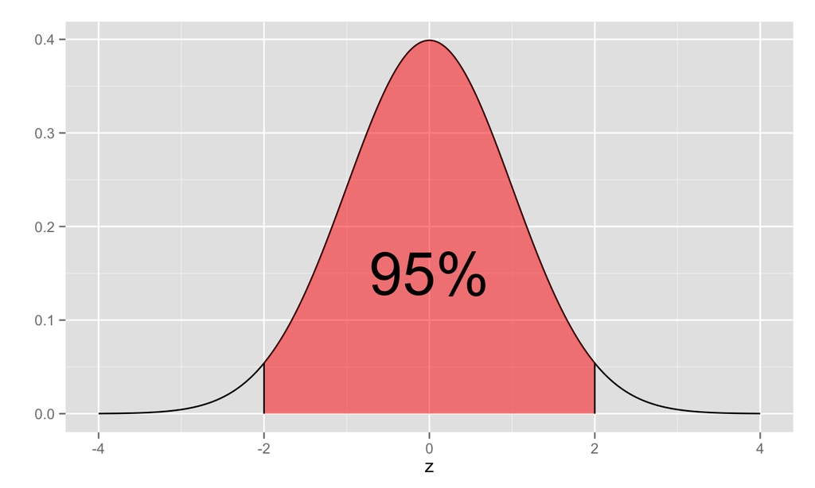

## 68-95-99.7 rule

- Approximately 99.7% of observations are within \(3\sigma\) of the mean \(\mu\)
- If \(\mu = 0\) and \(\sigma = 1\), approximately 99.7% of the observations are between \(-3\) and \(3\)

## 68-95-99.7 rule

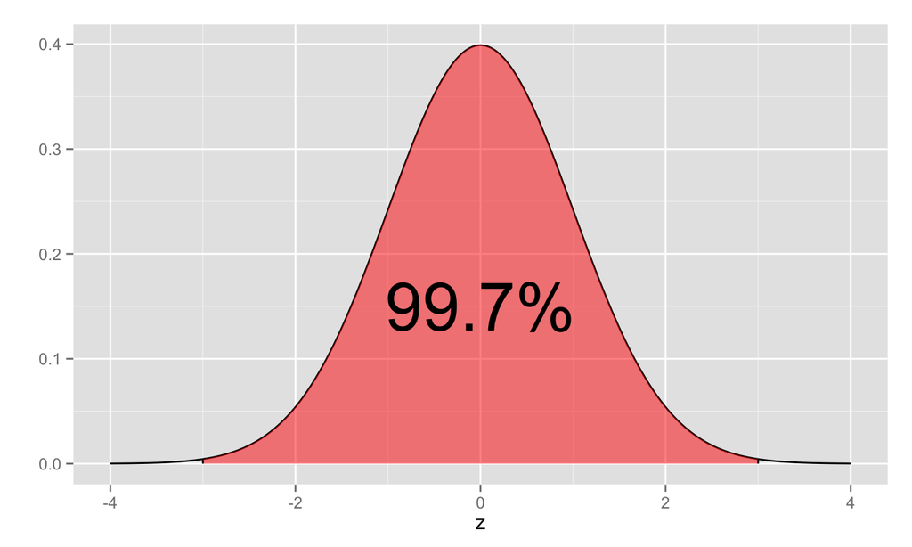

## Example - Height of men

- Height of men \(\sim N(70, 3)\)
- 68-95-99.7 rule
  - 68% of men will have heights between which two values?
    - \(\mu-\sigma = 70 - 3 = 67\) inches
    - \(\mu+\sigma = 70 + 3 = 73\) inches

## Example - Height of men

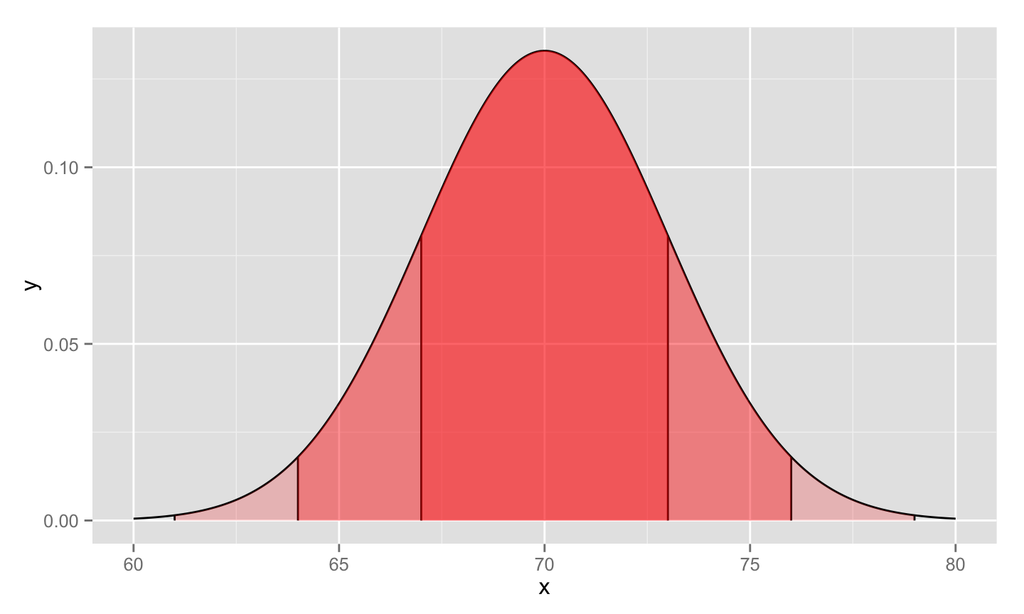

## 68% rule implies

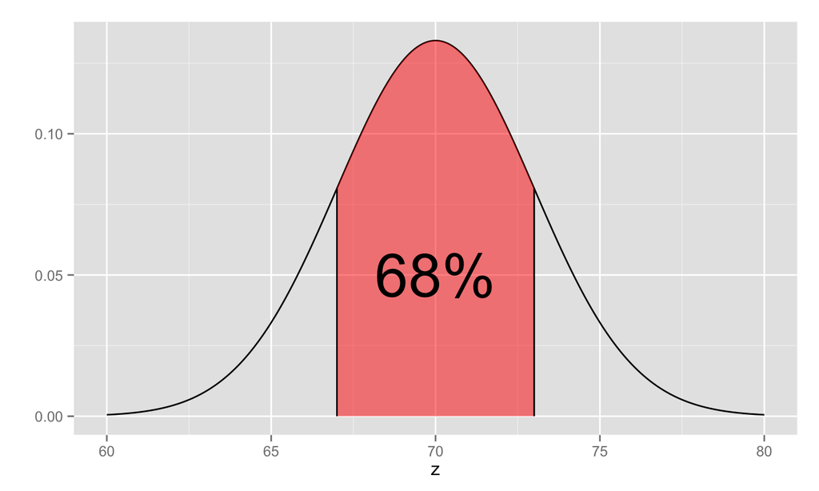

## 68% rule implies

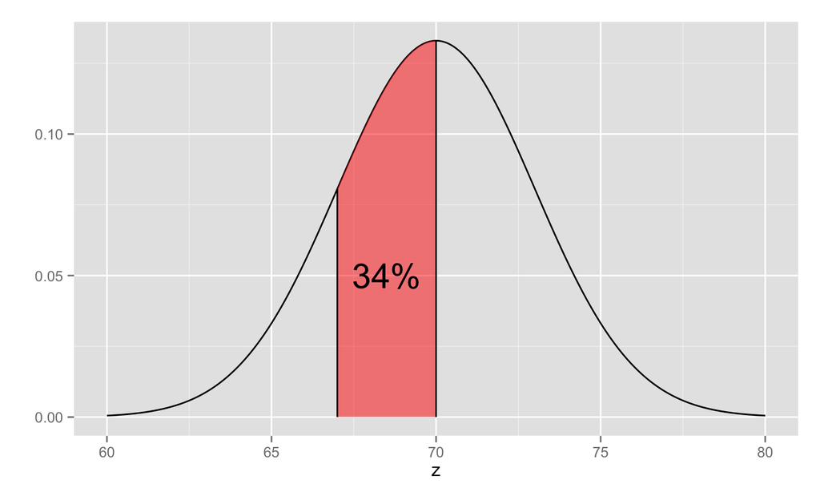

## 68% rule implies

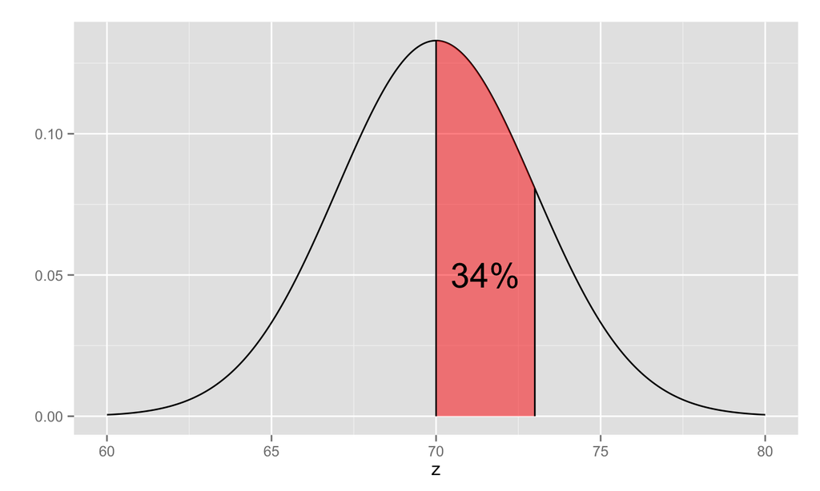

## 68% rule implies

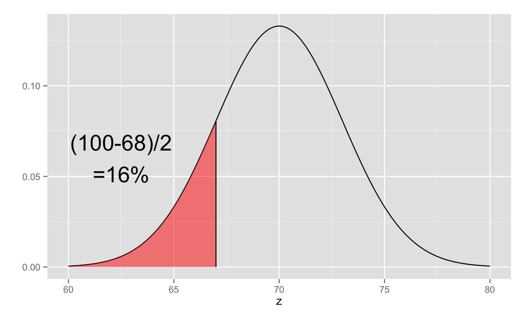

## 68% rule implies

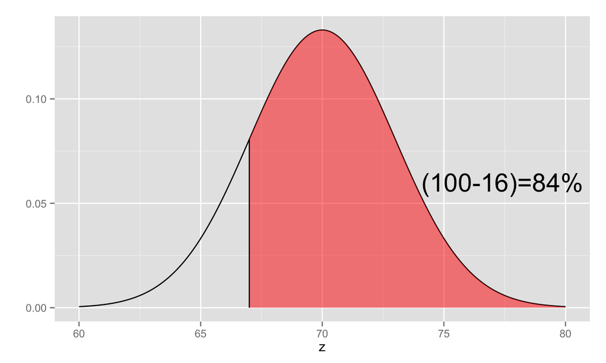

## 68% rule implies

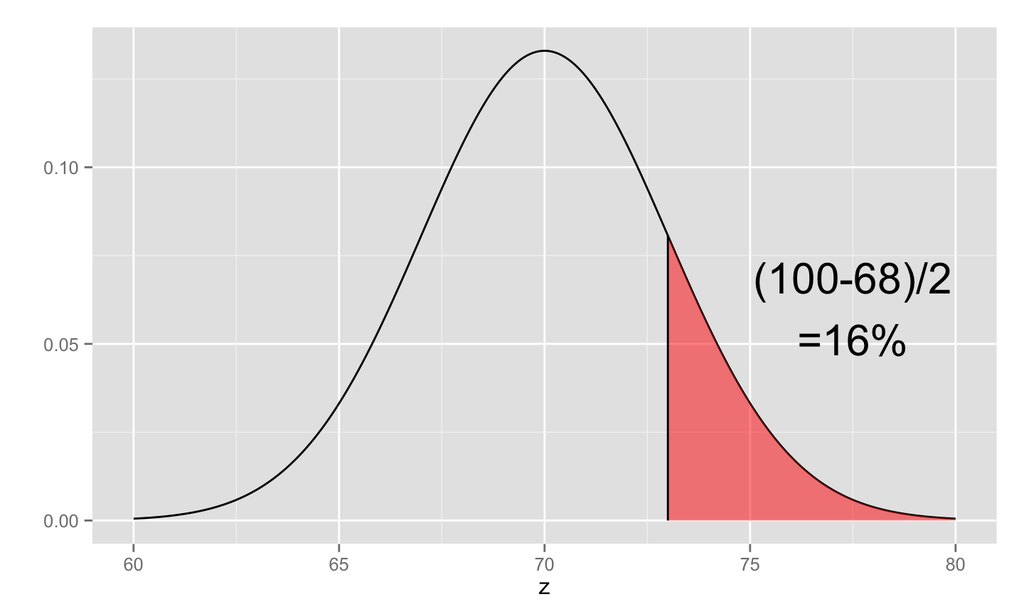

## 68% rule implies

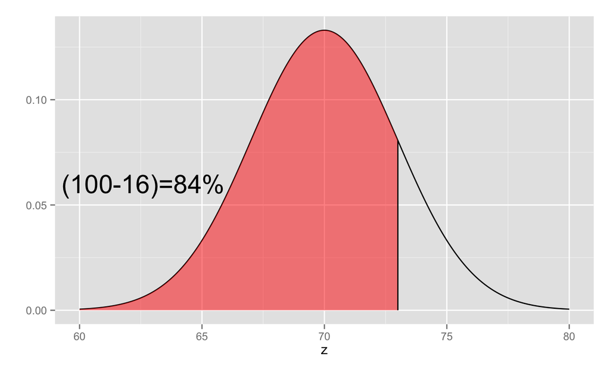

## Beyond the 68-95-99.7 rule

- Z-table
  - Connection between normal values and percentiles for standard normal model
- Standard normal model
  - Denoted by \(Z\)
  - Mean \(\mu = 0\)
  - Standard deviation \(\sigma = 1\)

## Finding percentiles and areas for given observations from a normal model

## Z Table

- Table gives proportion of curve below a particular \(z\) score (the percentile for the value \(z\))
  - \(z\) values range from \(-3.90\) to \(3.90\) on the table
  - Row - ones and tenths place for \(z\)
  - Column - hundredths place for \(z\)

## Percentile for z = -1.50

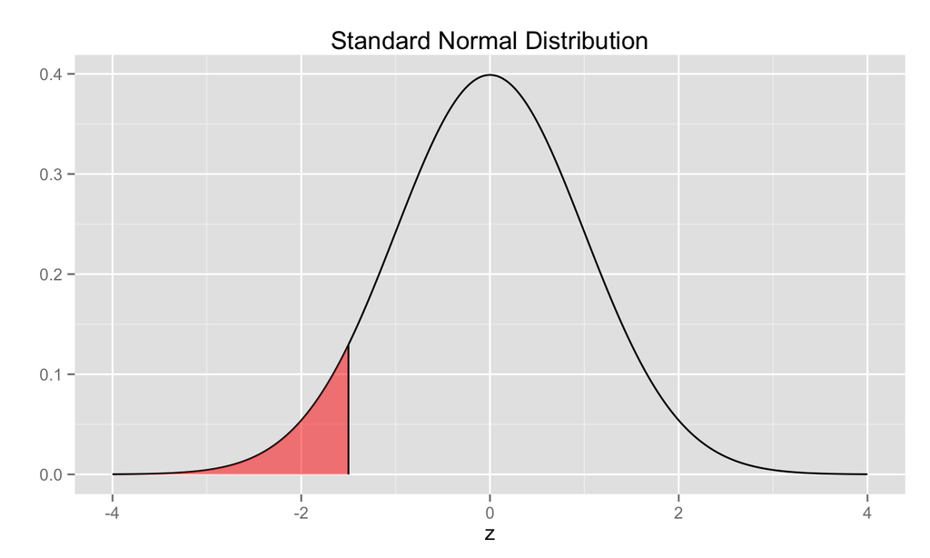

## Percentile for z = -1.50

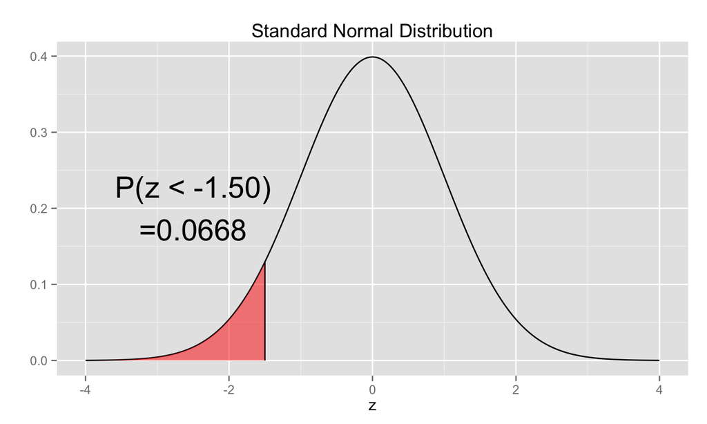

## Percentile for z = 1.98

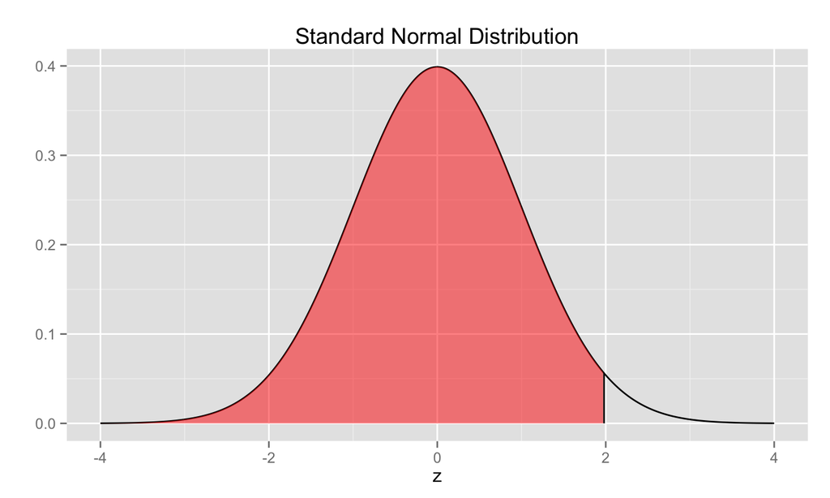

## Percentile for z = 1.98

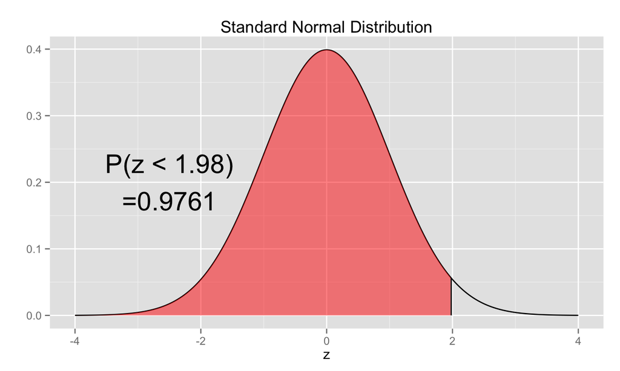

## Proportion greater than z = -1.65

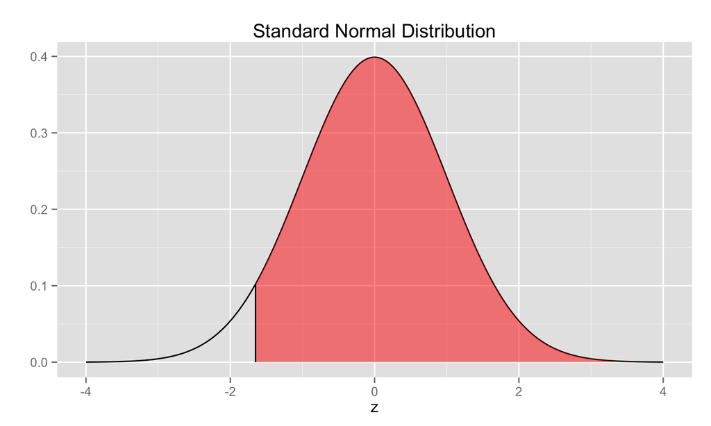

## Proportion greater than z = -1.65

[figure not shown]

## Proportion greater than z = 0.73

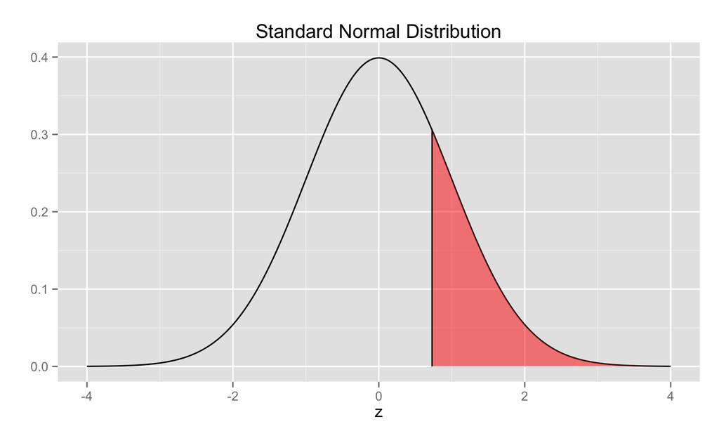

## Proportion greater than z = 0.73

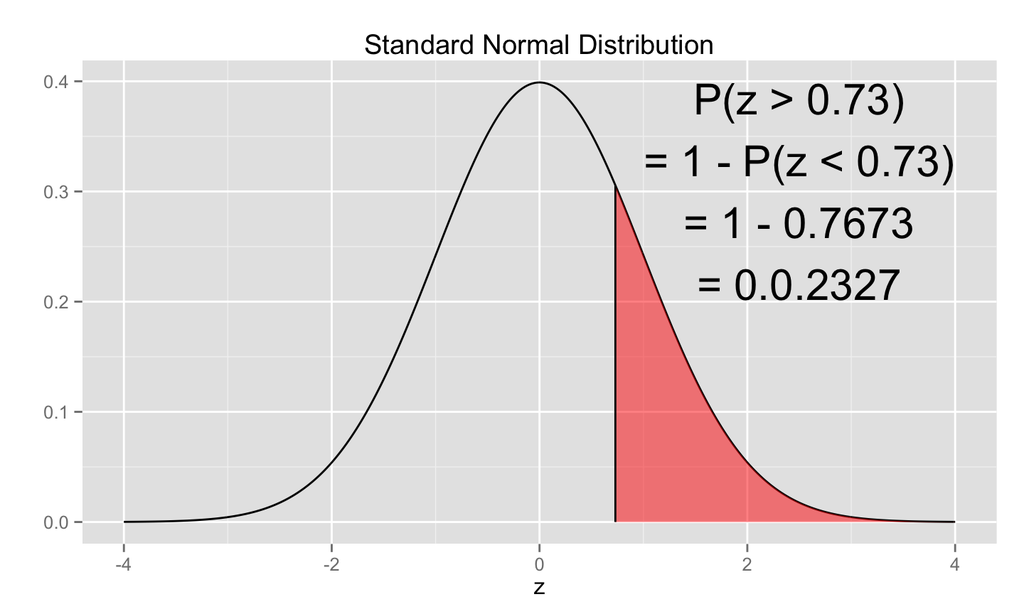

## Proportion between z = 0.5 and z = 1.4

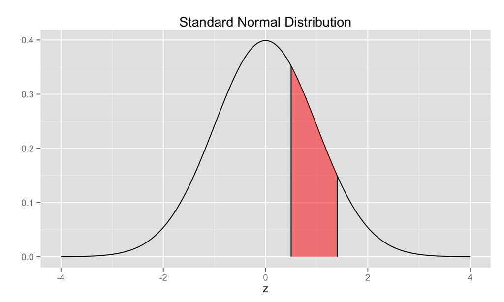

## Proportion between z = 0.5 and z = 1.4

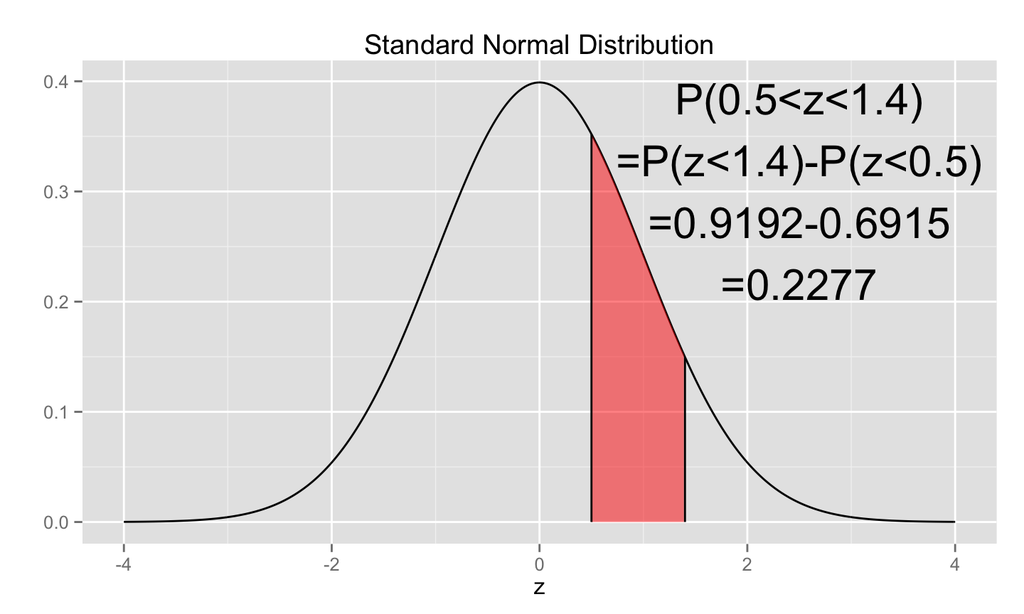

## Proportion between z = -2.3 and z = -0.05

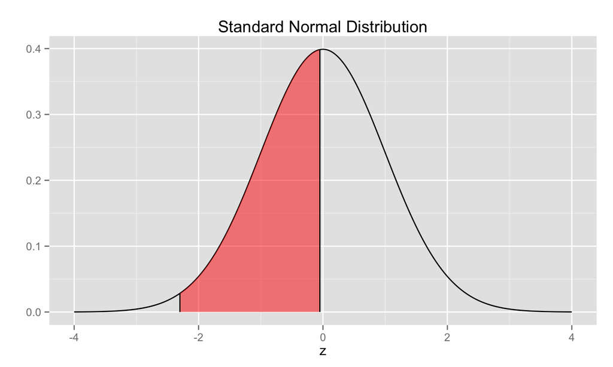

## Proportion between z = -2.3 and z = -0.05

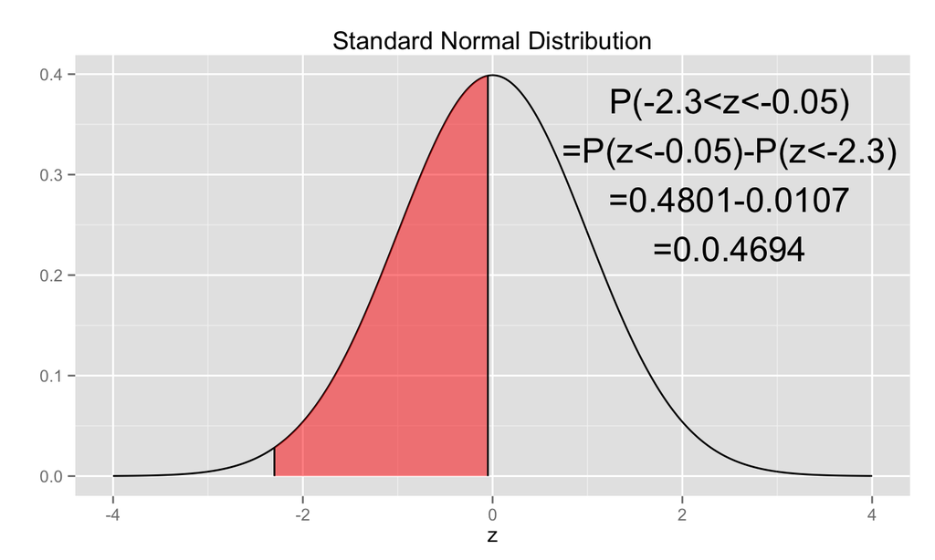

## Finding z from a given percentile

## Finding z from a given percentile

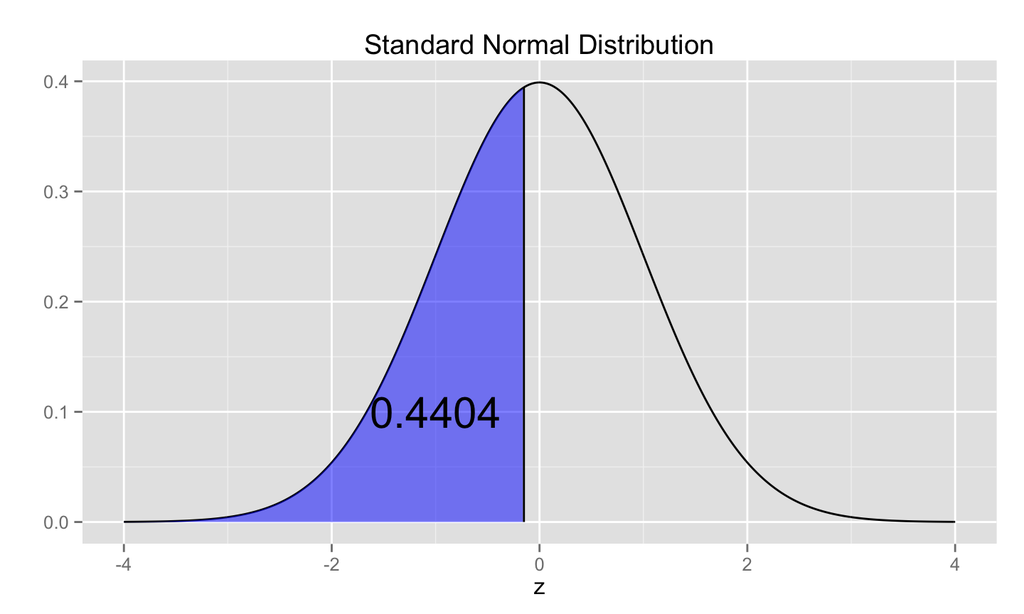